# Stochastic sims

Ben Bolker

12:25 25 July 2016

```r
library(fitsir)
library(bbmle) ## needed for coef() ...
library(splines) ## for ns()
library(plyr)  ## for raply()
library(dplyr)
library(tibble)
library(tidyr)
library(ggplot2); theme_set(theme_bw())
library(gridExtra)
library(ggstance) ## for horizontal violins
```

```r
source("stochsim_funs.R")
```

```r
set.seed(101)
s0 <- simfun(rpars=list(size=10))
```

Various ways of fitting …

```r
## get starting values and trajectory based on them
## ss0 <- startfun(auto=TRUE,data=s0)
## use the generic (bad!) starting values
ss0 <- startfun()
ss2 <- SIR.detsim(s0$tvec,unlist(trans.pars(ss0)))

## fit and corresponding trajectory
t1 <- system.time(f1 <- fitsir(s0,start=ss0))
ss3 <- SIR.detsim(s0$tvec,trans.pars(coef(f1)))

## GAM fit: match number of degrees of freedom
## glm() lists df as df+2

##   counting for intercept and residual var(?)
m1 <- glm(count~ns(tvec,df=3),
          family=gaussian(link="log"),data=s0)
```

`fitsir` works OK in this case even though we use the generic starting parameters (not auto-fit, which is currently broken):

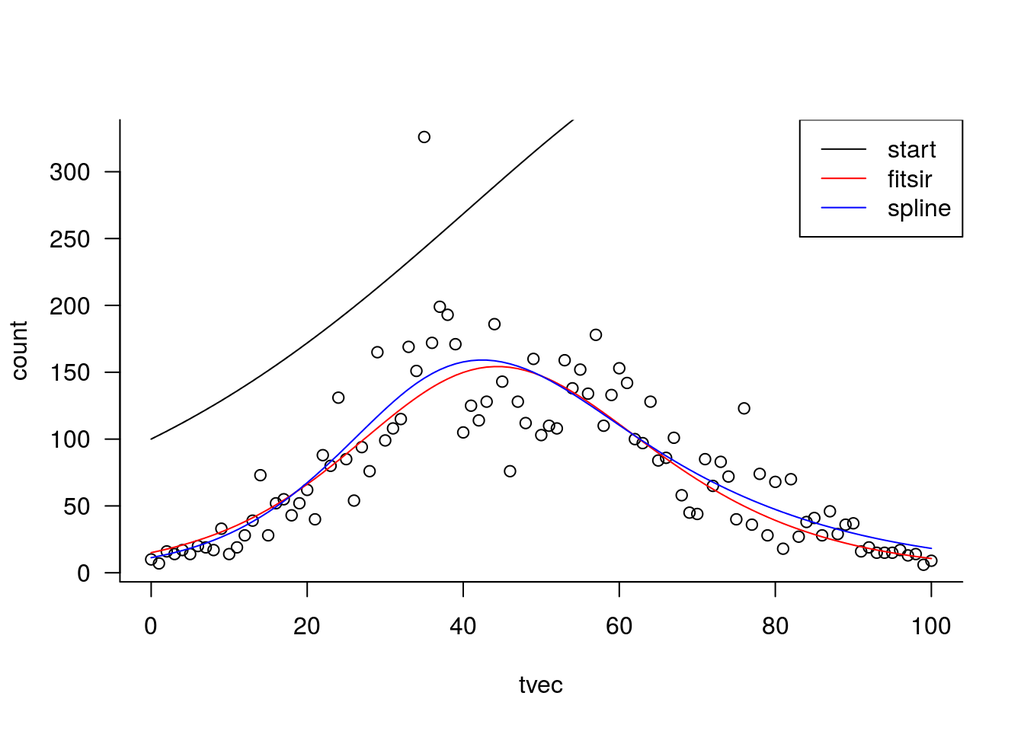

## Preliminary ensemble results

```r
## takes about 1 minute per sim ...
system.time(print(fitfun(s0)))
```

```
##                 t          log.beta         log.gamma             log.N
##         18.896000         -1.091505         -1.371839          8.383481
##           logit.i       (Intercept) ns(tvec, df = 3)1 ns(tvec, df = 3)2
##         -5.668077          2.424629          1.185673          3.756154
## ns(tvec, df = 3)3           nll.SIR           nll.gam
##         -1.345837        490.990084        487.924023
```

```
##    user  system elapsed
##   18.98    0.00   18.98
```

(autostart was used with these cached results …)

```r
simfn <- "stochsim.rda"
if (file.exists(simfn)) {
   load(simfn)
} else {
set.seed(101)
res1 <- raply(20,fitfun(simfun(rpars=list(size=10))),
              .progress="text")
}
```

How well does this work?

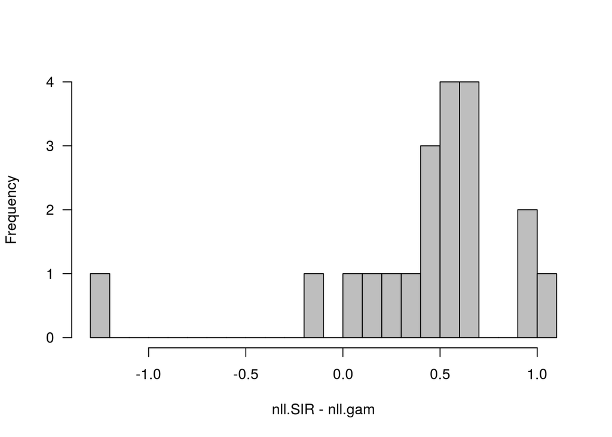

## Notes/preliminary conclusions

- these are fits to a reasonably well-behaved (although fairly noisy simulation example)
- with the current “autofit” functionality, `fitsir` mostly works OK, doesn’t need Latin hypercube for this example
- in 20 sims, GAM/spline fit does slightly better most (90%) of the time, but not a big difference (<2 log-likelihood units)

```r
fitfun(s0)[c("nll.SIR","nll.gam")]
```

```
##  nll.SIR  nll.gam
## 490.9901 487.9240
```

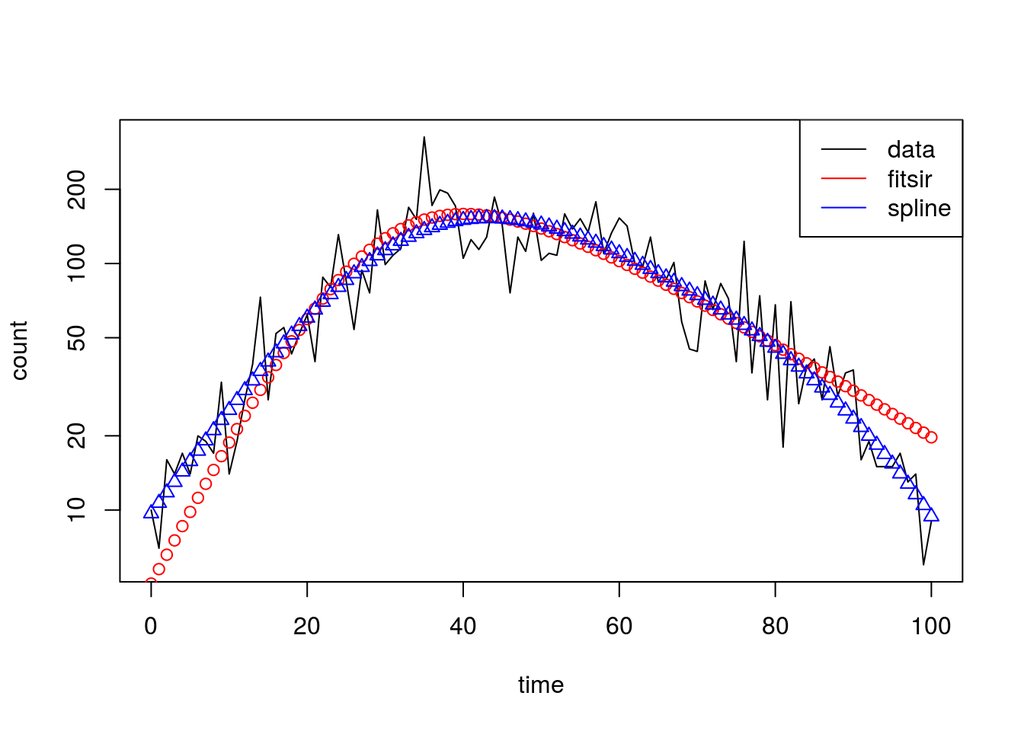

```
##        time    log.beta   log.gamma       log.N     logit.i     nll.SIR
##   8.1770000  -1.6773849  -3.0065601   6.0184961  -4.3899524 487.7802538
## nll.spline2  mse.fitsir mse.spline1 mse.spline2
##  27.5448590   0.2299535   0.1231089   0.1265969
```

```r
fitfun2(s0,plot.it=TRUE,log="y")
```

```r
sizevec <- 10^seq(0,2,length.out=20)
repvals <- 1:10
sres <- data.frame(expand.grid(size=sizevec,rep=repvals),
                   cbind(fitsir=NA,spline=NA))
set.seed(101)
for (i in 1:nrow(sres)) {
    sres[i,3:4] <-
        fitfun2(simfun(rpars=list(size=sres[i,"size"])))
}
```

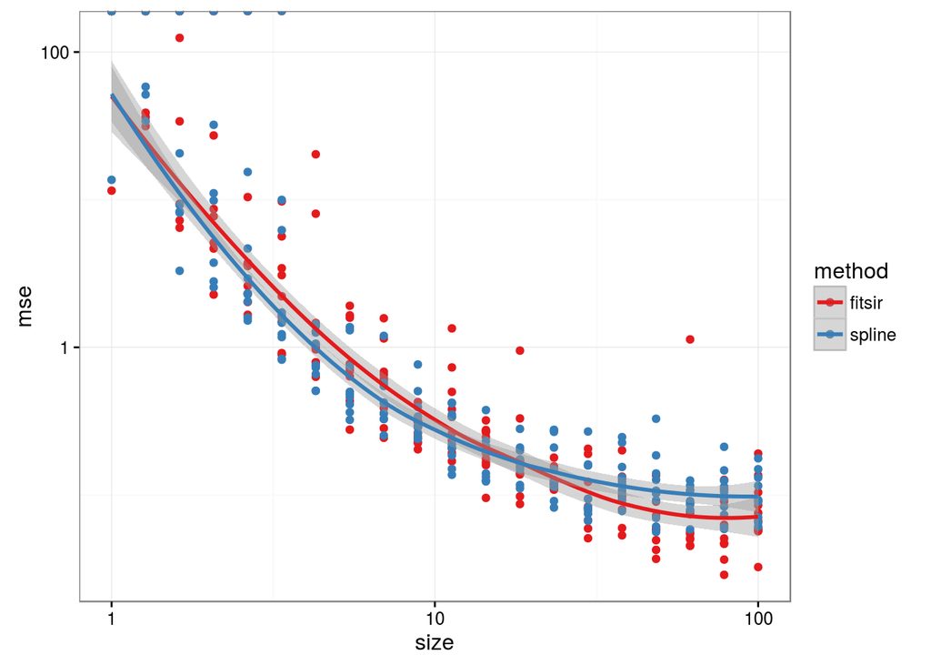

```r
sres2 <- gather(sres,method,mse,-size,-rep)
ggplot(sres2,aes(size,mse,colour=method))+
    scale_x_log10()+
    scale_y_log10()+
    geom_point()+geom_smooth()+scale_colour_brewer(palette="Set1")
```

We may need pretty small `size` values to get match the observed range of mean-squared error values …

A first crack at comparing `fitsir` and spline (three ways to do this – (1) true start values; (2) generic start values; (3) LHS of starting values, pick best)

```r
simfn2 <- "stochsim2.rda"
fitfun.optim <- function(data) {
    t1 <- system.time(f1 <- fitsir.optim(data,start=startfun(auto=TRUE,data=data)))
    m1 <- glm(count~ns(tvec,df=3),family=gaussian(link="log"),data=data)
    res <- c(t=unname(t1["elapsed"]),coef(f1),
      nll.SIR=c(-logLik(f1)),nll.gam=c(-logLik(m1)))
    return(res)
}

if (file.exists(simfn2)) {
   load(simfn2)
} else {
    set.seed(101)
    res1 <- raply(20,fitfun(simfun(rpars=list(size=10))))
    save("res1",file=simfn2)
}
```

## Ranges

from Dora:

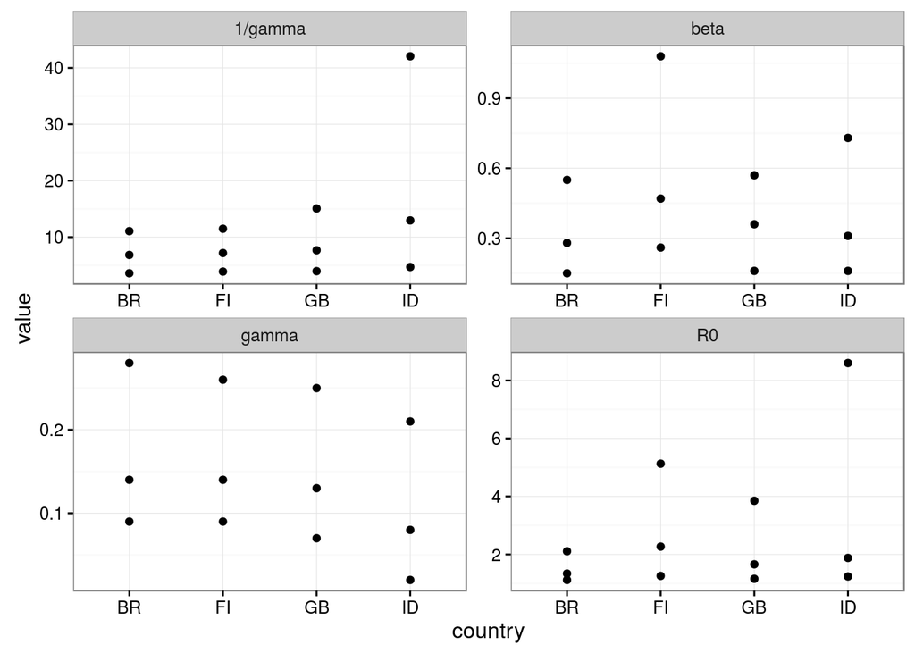

```r
Nquant <- setNames(
    c(9.908985e+00,4.492488e+02,2.096015e+03,2.878854e+04,2.865343e+31),
    seq(0,100,by=25))
I0quant <-  setNames(
    c(6.573213e-193,6.255714e-04,9.216386e-03,4.933392e-02,9.990980e-01),
    seq(0,100,by=25))

m0 <- matrix(c(1.16,1.66,3.85,3.98,7.68,15.08,0.16,0.36,0.57,0.07,0.13,0.25,
         1.12,1.34,2.11,3.61,6.85,11.07,0.15,0.28,0.55,0.09,0.14,0.28,
         1.26,2.27,5.13,3.90,7.19,11.49,0.26,0.47,1.08,0.09,0.14,0.26,
         1.24,1.88,8.60,4.71,12.97,42.06,0.16,0.31,0.73,0.02,0.08,0.21),
         ncol=4)
dimnames(m0) <- list(paste(rep(c("R0","1/gamma","beta","gamma"),each=3),
                     rep(paste0("Q",1:3),4),sep="_"),
                     c("GB","BR","FI","ID"))
m1 <- m0 %>% as.data.frame %>% rownames_to_column("var") %>%
    separate(var,c("var","quantile"),sep="_") %>%
    gather(country,value,-c(var,quantile))
## mutate(qq=as.numeric(gsub("Q","",quantile))*0.25)
ggplot(m1,aes(country,value))+geom_point()+
    facet_wrap(~var,scale="free")
```

- get parameter ranges from DR: $\beta$, $\gamma$, $N$, $I(0)$, and number of data points (for simplicity we will take the same overall time range, and use number of data points for `dt`)
- calibrate neg binomial size parameter to observed mean squared error
- larger sample
- parameters more typical of DR/music-download data: esp. more samples (will presumably make differences *more* significant/favour GAMs more?)
- try factorial experiment:
  - multiple sims
  - range of sample sizes
  - range of true parameter values (Latin hypercube??)

## comparing smooth.spline and `lm(y~ns())`

How do we fit a reasonable spline model of equivalent complexity to `fitsir` (with 4 total parameters)?

`?ns` says

> One can supply ‘df’ rather than knots; ‘ns()’ then chooses ‘df - 1 - intercept’ knots …

however, the `df` refers to the number of *spline* degrees of freedom; if we set `df=3` we get 4 parameters (intercept+3). `smooth.spline` with $k$ knots gives $k+2$ coefficients (but it’s almost impossible to make it work with $k=2$ knots )

```r
set.seed(101)
dx <- data.frame(x=rnorm(100),y=rnorm(100))
length(coef(lm(y~ns(x,df=3),data=dx)))
```

```
## [1] 4
```

```r
ss <- with(dx,smooth.spline(x,y,nknots=4))
length(ss$fit$coef)
```

```
## [1] 6
```

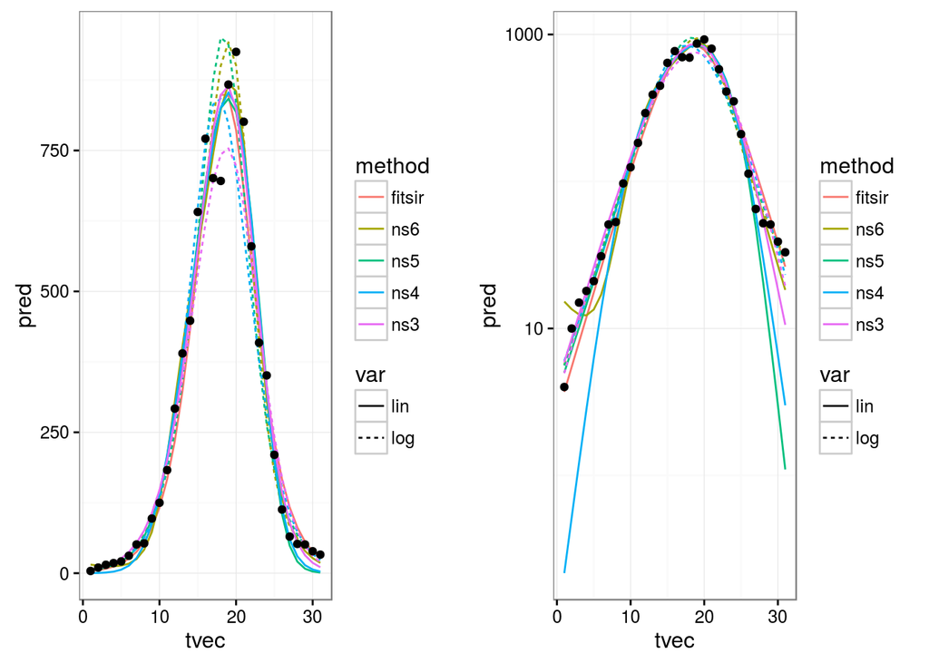

## stoch sim batch results

Order of columns in sim output is:

- 1,2: fitsir with “auto” and “true” start
- 3: smooth spline with 6 coefficients (minimum practical)
- 4,5: `ns()` with 4 coefficients, lin/log scale criterion
- 6,7: `ns()` with 6 coeff, ditto

It turns out the fits with the linear-scale criterion have *terrible* MSEs, leaving these out for now.

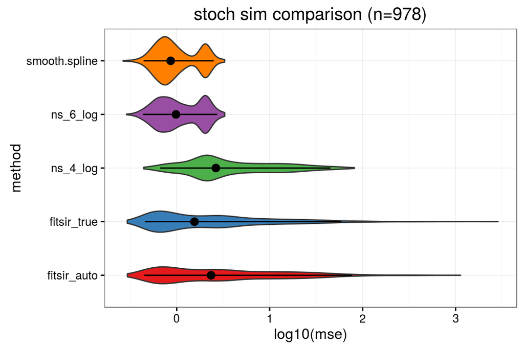

(points/bars are median, 95% quantiles)

Conclusions:

- `smooth.spline` with 6 coefficients (= 4 knots), and `ns()` with 6 coefficients (`spline.df` = 5) give approximately equal MSE distributions, better than the rest (but have more parameters)
- `ns()` with 4 coefficients (`spline.df`=3) does worse (median) than `fitsir`, but worst-case scenario is better …
- `fitsir` starting from true parameter values (best-case scenario?) does slightly better than the auto-start, but not huge differences